# Clustering 3K PBMCs with Bioconductor

Author

Kevin Rue-Albrecht

*Generated: 2026-05-28 13:01:14*

## Libraries

```r
library(bluster)
library(cowplot)
library(DropletUtils)
library(scater)
library(scran)
library(scuttle)
```

## Data

### Data download

To create a parallel tutorial to the existing tutorial [Clustering 3K PBMCs with Seurat](https://training.galaxyproject.org/training-material/topics/single-cell/tutorials/scrna-seurat-pbmc3k/tutorial.html), input data files were downloaded from these Zenodo links:

```
https://zenodo.org/record/3581213/files/genes.tsv
https://zenodo.org/record/3581213/files/barcodes.tsv
https://zenodo.org/record/3581213/files/matrix.mtx
```

#### Create a SingleCellExperiment Object

```r
sce <- DropletUtils::read10xCounts(samples = "data")
```

> A Galaxy tool wrapper exists, [DropletUtils Read10x](https://usegalaxy.eu/?tool_id=toolshed.g2.bx.psu.edu%2Frepos%2Febi-gxa%2Fdropletutils_read_10x%2Fdropletutils_read_10x%2F1.0.4%2Bgalaxy0&version=latest), but produces an `rdata` file which needs to be manually re-typed to `rdata.sce` or `loom` depending on the downstream steps.

#### Switch to user-friendlier gene identifiers

Setting the rownames of the object to “uniquified gene symbols” makes later plots coloured by gene expression more human-friendly. See `scater::plotPCA(sce, colour_by = gene_id)`). Note that the real gene symbols remain available in `rowData(sce)[["Symbol"]]`.

```r
rownames(sce) <- make.unique(rowData(sce)[["Symbol"]])
```

#### Inspect the `SingleCellExperiment` object.

```r
print(sce)
```

```
class: SingleCellExperiment
dim: 32738 2700
metadata(1): Samples
assays(1): counts
rownames(32738): MIR1302-10 FAM138A ... AC002321.2 AC002321.1
rowData names(2): ID Symbol
colnames: NULL
colData names(2): Sample Barcode
reducedDimNames(0):
mainExpName: NULL
altExpNames(0):
```

> New Galaxy tool wrapper needed here, simply to run `print(sce)` into a `txt` file for inspection.

## Preprocessing

### Computation of QC metrics

#### Identify mitochondrial genes.

```r
mt_gene_ids <- rownames(sce)[grep('^MT-', rowData(sce)[["Symbol"]])]
mt_gene_ids
```

```
 [1] "MT-ND1"  "MT-ND2"  "MT-CO1"  "MT-CO2"  "MT-ATP8" "MT-ATP6" "MT-CO3"
 [8] "MT-ND3"  "MT-ND4L" "MT-ND4"  "MT-ND5"  "MT-ND6"  "MT-CYB"
```

> New Galaxy Tool needed to run the code above. The [Single-cell quality control with scater](https://training.galaxyproject.org/training-material/topics/single-cell/tutorials/scrna-scater-qc/tutorial.html) tutorial provides a precomputed file of mitochondrial genes.

#### Calculate the Proportion of Mitochondrial Reads

```r
gene_subsets <- list()
gene_subsets[["MT"]] <- mt_gene_ids
sce <- scuttle::addPerCellQCMetrics(
    x = sce,
    subsets = gene_subsets
)
```

> A Galaxy Tool wrapper exists, [Scater: calculate QC metrics](https://usegalaxy.eu/?tool_id=toolshed.g2.bx.psu.edu%2Frepos%2Fiuc%2Fscater_create_qcmetric_ready_sce%2Fscater_create_qcmetric_ready_sce%2F1.22.0&version=latest), but requires the expression matrix in tabular format.

### Filtering of low-quality cells

#### Visualise QC Metrics.

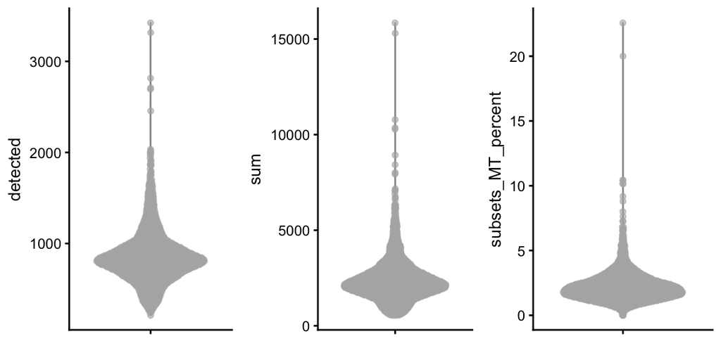

```r
plot_list <- list()
plot_list[["detected"]] <- scater::plotColData(
    object = sce,
    y = "detected"
)
plot_list[["sum"]] <- scater::plotColData(
    object = sce,
    y = "sum"
)
plot_list[["subsets_MT_percent"]] <- scater::plotColData(
    object = sce,
    y = "subsets_MT_percent"
)
cowplot::plot_grid(plotlist = plot_list, nrow = 1)
```

> TODO: check for existing wrapper Note: In contrast to `Seurat`, `scater` can only plot one QC metric at a time. We can use `cowplot` to combine them into a single figure.

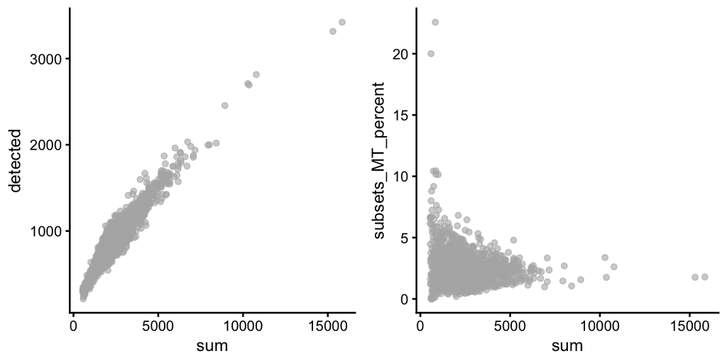

```r
plot_list <- list()
plot_list[["detected"]] <- scater::plotColData(
    object = sce,
    y = "detected",
    x = "sum"
)
plot_list[["subsets_MT_percent"]] <- scater::plotColData(
    object = sce,
    y = "subsets_MT_percent",
    x = "sum"
)
cowplot::plot_grid(plotlist = plot_list, nrow = 1)
```

#### Filter Out Low Quality Cells

```r
keep_cells <- sce$detected >= 200 & sce$detected <= 2500 & sce$subsets_MT_percent <= 5
sce <- sce[keep_cells, ]
```

> TODO: check for existing wrapper

#### Re-Visualise QC Metrics

[figure not shown]

```r
plot_list <- list()
plot_list[["detected"]] <- scater::plotColData(
    object = sce,
    y = "detected"
)
plot_list[["sum"]] <- scater::plotColData(
    object = sce,
    y = "sum"
)
plot_list[["subsets_MT_percent"]] <- scater::plotColData(
    object = sce,
    y = "subsets_MT_percent"
)
cowplot::plot_grid(plotlist = plot_list, nrow = 1)
```

[figure not shown]

```r
plot_list <- list()
plot_list[["detected"]] <- scater::plotColData(
    object = sce,
    y = "detected",
    x = "sum"
)
plot_list[["subsets_MT_percent"]] <- scater::plotColData(
    object = sce,
    y = "subsets_MT_percent",
    x = "sum"
)
cowplot::plot_grid(plotlist = plot_list, nrow = 1)
```

> TODO: check for existing wrapper

### Further Preprocessing

#### Separate Preprocessing Steps

```r
sce <- scuttle::logNormCounts(x = sce)
```

```r
allf <- scran::modelGeneVar(x = sce)
hvgs <- scran::getTopHVGs(allf, n = 2000)
```

> TODO: check for existing Galaxy tool wrapper. The wrapper should output both: - the table of statistics for later plotting (tsv) - the identifiers of highly variable genes (txt)

```r
message("No direct equivalent to Seurat ScaleData")
```

```
No direct equivalent to Seurat ScaleData
```

> TODO: check when this might have an impact on the rest of the tutorial

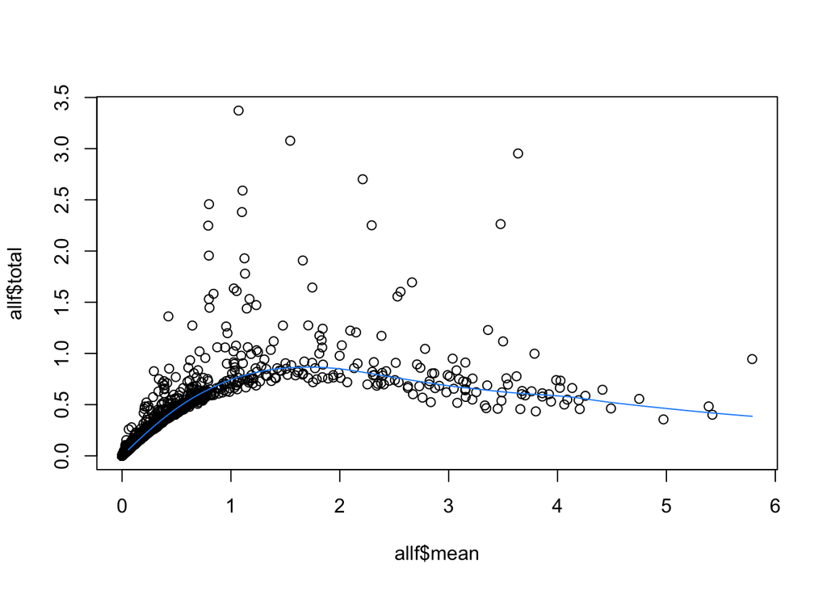

```r
plot(allf$mean, allf$total)
curve(metadata(allf)$trend(x), add=TRUE, col="dodgerblue")
```

> TODO: check for existing Galaxy tool wrapper. Note that there is no packaged function available for this. Both the help page and the OSCA book give base R code for quick inspection. A Galaxy Tool wrapper could easily produce a nicer ggplot2 graphics including labels for the top N genes as in the Seurat tutorial.

## Dimensionality Reduction

### Principal Component Analysis

#### Perform the PCA

```r
sce <- scater::runPCA(
    x = sce,
    ncomponents = 50,
    subset_row = hvgs
)
```

> TODO: check for existing Galaxy tool wrapper.

### Visualise the PCA Results

#### Visualise the PCA Results - Dimensional Loadings

```r
message("No direct equivalent to Seurat VizDimLoadings")
```

```
No direct equivalent to Seurat VizDimLoadings
```

> TODO: check when this might have an impact on the rest of the tutorial

#### Visualise the PCA Results - DimPlot

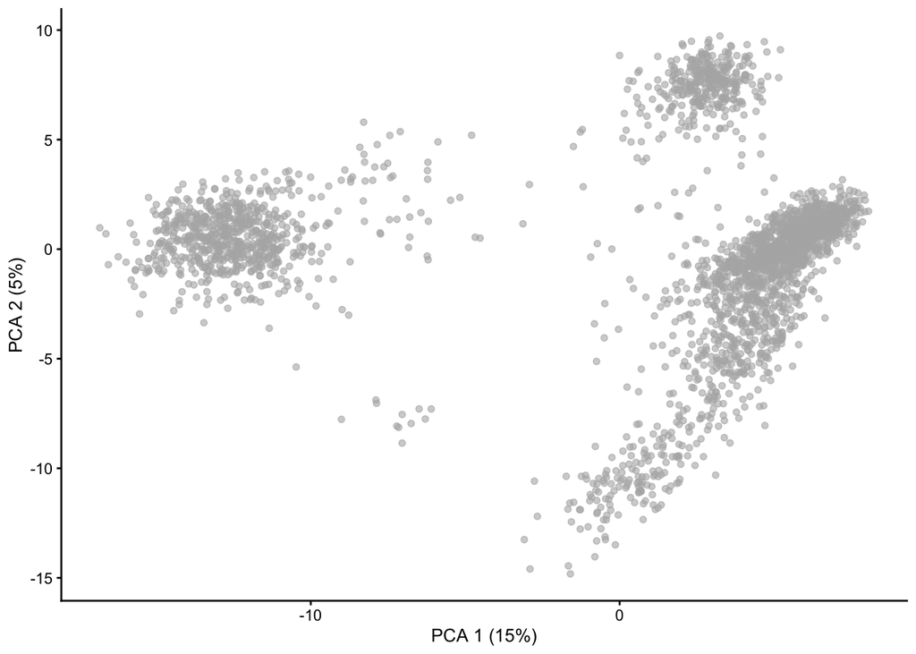

```r
scater::plotPCA(sce)
```

> TODO: check for existing Galaxy tool wrapper.

#### Visualise the PCA Results - Feature Plots

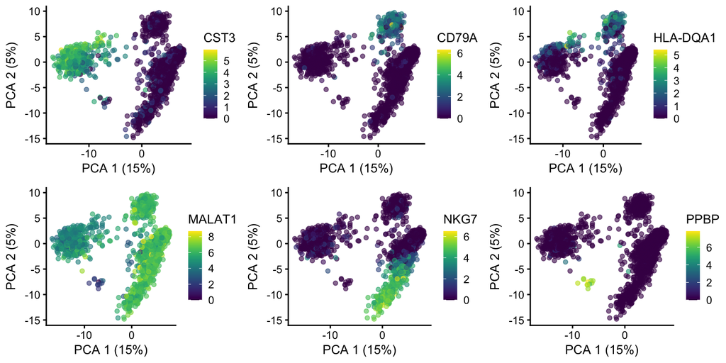

```r
plot_list <- list()
for (gene_id in c("CST3", "CD79A", "HLA-DQA1", "MALAT1", "NKG7", "PPBP")) {
    plot_list[[gene_id]] <- scater::plotPCA(
        object = sce,
        ncomponents = c(1, 2),
        colour_by = gene_id
    )
}
cowplot::plot_grid(plotlist = plot_list, nrow = 2)
```

Same for PC2 and PC3.

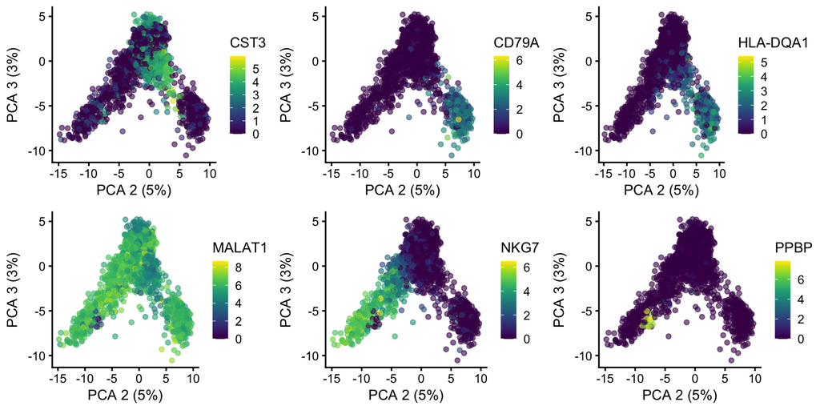

```r
plot_list <- list()
for (gene_id in c("CST3", "CD79A", "HLA-DQA1", "MALAT1", "NKG7", "PPBP")) {
    plot_list[[gene_id]] <- scater::plotPCA(
        object = sce,
        ncomponents = c(2, 3),
        colour_by = gene_id
    )
}
cowplot::plot_grid(plotlist = plot_list, nrow = 2)
```

> TODO: check for existing Galaxy tool wrapper. Note: this relies on the “uniquified gene symbol” rather than the actual gene symbol (available in `rowData(sce)[["Symbol"]]`). This ensures that every single feature in the dataset can be plotted whether or not it has a unique gene symbol or not.

#### Visualise the PCA Results - Heatmaps

```r
message("No direct equivalent to Seurat::DimHeatmap")
```

```
No direct equivalent to Seurat::DimHeatmap
```

### Determine the ‘dimensionality’ of the dataset

#### Make an Elbow Plot

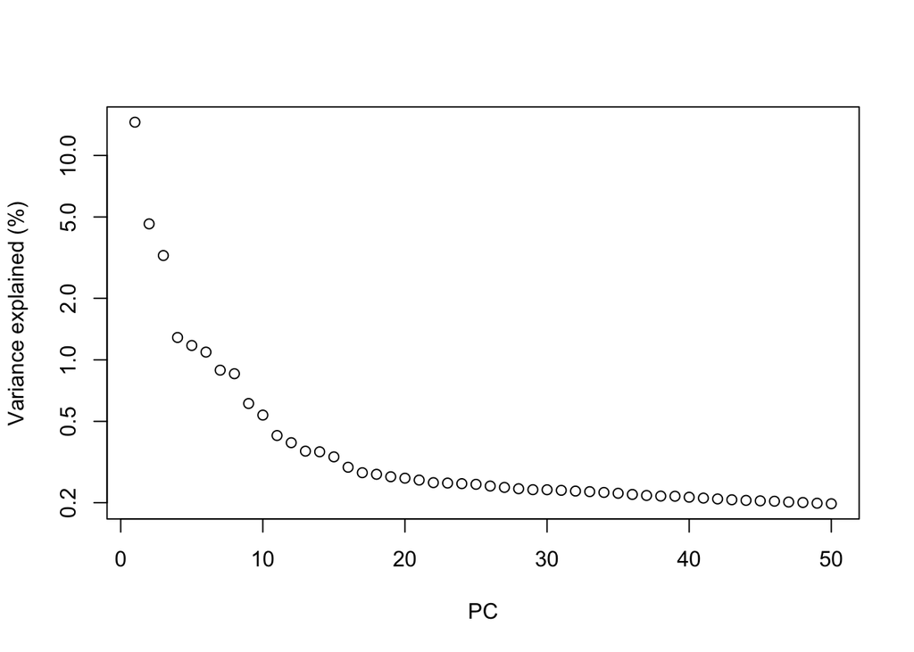

```r
percent.var <- attr(reducedDim(sce), "percentVar")
plot(percent.var, log="y", xlab="PC", ylab="Variance explained (%)")
```

> TODO: check for existing Galaxy tool wrapper.

## Cluster the Cells

```r
colData(sce)[["cluster"]] <- clusterCells(
    x = sce,
    use.dimred = "PCA",
    BLUSPARAM = bluster::SNNGraphParam(
        k = 10,
        type="rank",
        cluster.fun = "walktrap"
    )
)
```

> TODO: check for existing Galaxy tool wrapper.